# StreamCatTools Demo

Marc Weber

03 August, 2020

## Install StreamCatTools

Also make sure you have nhdplusTools installed - I am leveraging some functions from that package to complement grabbing Streamcat data. I’m also using mapview package.

```r
# requires devtools to install
# install.packages('devtools')
library(devtools)

# install from repository
# install_github('USEPA/StreamCatTools')
library(StreamCatTools)
library(sf)
library(nhdplusTools)
library(readr)
library(mapview)
library(dplyr)
library(knitr)
library(readr)
library(purrr)
library(tidyr)
library(ggplot2)
library(jsonlite)
```

## Example One

Get a list of available StreamCat values for certain parameters using the `get_streamcat_params` function (right now just metric names and areas of interest for this function) via the API

```r
area_params <- get_streamcat_params(param='area')
name_params <- get_streamcat_params(param='name')
print(paste0('Area of interest available parameters are: ', paste(area_params,collapse = ', ')))
```

```
## [1] "Area of interest available parameters are: catchment, watershed, riparian_catchment, riparian_watershed, other"
```

```r
print(paste0('A selection of available StreamCat metrics include: ',paste(name_params[1:10],collapse = ', ')))
```

```
## [1] "A selection of available StreamCat metrics include: rddens, pctglaclakefine, tmax8110, pcthbwet2011, pcturbmd2001, pcturbmd2006, pctglactilloam, rdcrs, pcthay2006, pctfire2007"
```

## Example Two

Access several variables for several areas of interest and a couple COMIDs using theh `get_streamcat_data` function. Loads data into a tibble we can view.

```r
df <- get_streamcat_data(metric='PctUrbMd2006,DamDens,TRIDens', aoi='riparian_catchment,catchment,watershed', comid='179,1337,1337420')
```

```
## &name=PctUrbMd2006,DamDens,TRIDens&comid=179,1337,1337420&areaOfInterest=riparian_catchment,catchment,watershed
```

```r
kable(df)
```

| COMID | CATAREASQKM | WSAREASQKM | CATAREASQKMRP100 | TRIDENSCATRP100 | PCTURBMD2006CATRP100 | TRIDENSCAT | TRIDENSWS | PCTURBMD2006CAT | PCTURBMD2006WS | DAMDENSCAT | DAMDENSWS |
| --- | --- | --- | --- | --- | --- | --- | --- | --- | --- | --- | --- |
| 1337 | 2.5803 | 2.5803 | 0.2781 | 0 | 0 | 0 | 0 | 0 | 0 | 0 | 0.0000000 |
| 179 | 3.5550 | 3.5550 | 0.5373 | 0 | 0 | 0 | 0 | 0 | 0 | 0 | 0.0000000 |
| 1337420 | 3.4101 | 60.8517 | 0.2925 | 0 | 0 | 0 | 0 | 0 | 0 | 0 | 0.0328668 |

## Example Three

We can actually pull data into R from the StreamCat API by simply using `read_csv` function from the `readr` package. We have to hard-wire paramaters and are limited in number of records returned through a `GET` request

```r
df <- read_csv("http://v26267mcpk506/StreamCat/v1/stable/metrics?name=fert&areaOfInterest=watershed&comid=179")
kable(df)
```

| COMID | WSAREASQKM | FERTWS |
| --- | --- | --- |
| 179 | 3.555 | 1.437975 |

## Example Four

```r
df <- get_streamcat_data(metric='PctWdWet2006', aoi='watershed', county='41003')
```

```
## &name=PctWdWet2006&areaOfInterest=watershed&county=41003
```

```r
kable(head(df))
```

| COMID | FIPS | WSAREASQKM | PCTWDWET2006WS |
| --- | --- | --- | --- |
| 23764519 | 41003 | 12.5856 | 0.3432494 |
| 23762751 | 41003 | 213.6753 | 1.0959620 |
| 23763039 | 41003 | 5.8509 | 2.9380095 |
| 23762873 | 41003 | 13.6341 | 0.6601096 |
| 23763313 | 41003 | 81.8478 | 0.5146137 |
| 23763023 | 41003 | 19.9863 | 2.4992120 |

## Example Five

```r
df <- get_streamcat_data(metric='PctWdWet2006', aoi='watershed', region='17')
```

```
## &name=PctWdWet2006&areaOfInterest=watershed&region=17
```

```r
kable(head(df))
```

| COMID | REGIONID | WSAREASQKM | PCTWDWET2006WS |
| --- | --- | --- | --- |
| 24345567 | Region17 | 6.9354 | 2.0503504 |
| 24345937 | Region17 | 0.9306 | 46.2282398 |
| 24345643 | Region17 | 7.3746 | 0.0000000 |
| 24345671 | Region17 | 1.1871 | 0.0000000 |
| 24345803 | Region17 | 94.5153 | 0.3056648 |
| 24345549 | Region17 | 1.7847 | 0.0000000 |

## Example Six

Access a single variable for the Calapooia River using `get_streamcat_data` function. Use `nhdplusTools` library to grab flowlines and watershed for the Calapooia, plot selected StreamCat metric for Calapooia and show the watershed.

```r
discover_nldi_sources()$source
```

```
## [1] "comid"    "huc12pp"  "nwissite" "wade"     "WQP"
```

```r
start_comid = 23763529
nldi_feature <- list(featureSource = "comid", featureID = start_comid)
discover_nldi_navigation(nldi_feature)
```

```
## $upstreamMain
## [1] "https://labs.waterdata.usgs.gov/api/nldi/linked-data/comid/23763529/navigate/UM"
##
## $upstreamTributaries
## [1] "https://labs.waterdata.usgs.gov/api/nldi/linked-data/comid/23763529/navigate/UT"
##
## $downstreamMain
## [1] "https://labs.waterdata.usgs.gov/api/nldi/linked-data/comid/23763529/navigate/DM"
##
## $downstreamDiversions
## [1] "https://labs.waterdata.usgs.gov/api/nldi/linked-data/comid/23763529/navigate/DD"
```

```r
flowline_nldi <- navigate_nldi(nldi_feature, mode = "upstreamTributaries", data_source = "")

# get StreamCat metrics
temp_dir <- 'C:/Users/mweber/temp'
nhdplus <- subset_nhdplus(comids = flowline_nldi$nhdplus_comid, output_file = file.path(temp_dir, "nhdplus.gpkg"),nhdplus_data = "download",overwrite = TRUE, return_data = FALSE)

st_layers(nhdplus)
```

```
## Driver: GPKG
## Available layers:
##            layer_name        geometry_type features fields
## 1 NHDFlowline_Network 3D Multi Line String      187     91
## 2         CatchmentSP        Multi Polygon      186      8
## 3             NHDArea        Multi Polygon        6     16
## 4        NHDWaterbody        Multi Polygon       17     23
```

```r
cats <- read_sf(dsn=nhdplus, layer='CatchmentSP')
comids <- paste(cats$featureid,collapse=",",sep="")

df <- get_streamcat_data(metric='PctImp2011', aoi='catchment', comid=comids)
```

```
## &name=PctImp2011&comid=23765999,23763555,23763615,23763651,23763585,23763623,23763863,23763649,23763805,23763655,23763563,23763559,23763677,23763813,23763641,23763581,23763551,23763575,23763659,23763803,23763605,23763807,23763531,23763625,23763537,23763635,23763637,23763675,23763535,23763865,2376…
```

```r
flowline_nldi$PCTIMP2011CAT <- df$PCTIMP2011CAT[match(flowline_nldi$nhdplus_comid, df$COMID)]

basin <- get_nldi_basin(nldi_feature = nldi_feature)

mapview(basin, alpha.regions=.08) + mapview(flowline_nldi, zcol = "PCTIMP2011CAT", legend = TRUE)
```

[interactive chart not shown]

## Example Seven

Grab NRSA data from NARS website directly in R, pull particular StreamCat metrics for sites using `get_streamcat_data`, and compare landscape metrics with other NRSA metrics

```r
nrsa <- read_csv('https://www.epa.gov/sites/production/files/2015-09/siteinfo_0.csv')
glimpse(nrsa)
```

```
## Rows: 2,320
## Columns: 34
## $ PUBLICATION_DATE <chr> "9/1/2015", "9/1/2015", "9/1/2015", "9/1/2015", "9...
## $ UID              <dbl> 10000, 10001, 10002, 10003, 10004, 10006, 10007, 1...
## $ SITE_ID          <chr> "FW08KS001", "FW08KS003", "FW08KS005", "FW08KS006"...
## $ YEAR             <dbl> 2008, 2008, 2008, 2008, 2008, 2008, 2008, 2008, 20...
## $ VISIT_NO         <dbl> 1, 1, 1, 1, 1, 1, 1, 1, 1, 1, 2, 1, 1, 1, 2, 1, 2,...
## $ DATE_COL         <chr> "5-Aug-08", "11-Aug-08", "22-Jul-08", "12-Aug-08",...
## $ STATE            <chr> "KS", "KS", "KS", "KS", "KS", "KS", "KS", "LA", "D...
## $ LOC_NAME         <chr> "Twelvemile Creek", "Turkey Creek", "Thomas Creek"...
## $ SITE_CLASS       <chr> "PROB", "PROB", "PROB", "PROB", "PROB", "PROB", "P...
## $ AGGR_ECO3_2015   <chr> "PLNLOW", "PLNLOW", "PLNLOW", "PLNLOW", "PLNLOW", ...
## $ AGGR_ECO9_2015   <chr> "SPL", "SPL", "TPL", "SPL", "TPL", "SPL", "TPL", "...
## $ ECO10            <chr> NA, "PL-RANGE", NA, NA, NA, NA, NA, NA, NA, "PL-NC...
## $ US_L3CODE_2015   <dbl> 27, 26, 40, 27, 28, 27, 40, 35, 63, 25, 63, 63, 13...
```

[output cut: 21 more lines]

```r
# Promote data frame to sf spatial points data frame
nrsa_sf <- st_as_sf(nrsa, coords = c("LON_DD83", "LAT_DD83"), crs = 4269)

# Get COMIDs using nhdplusTools package
# nrsa$COMID<- NA
# for (i in 1:nrow(nrsa_sf)){
#   print (i)
#   nrsa_sf[i,'COMID'] <- discover_nhdplus_id(nrsa_sf[i,c('geometry')])
# }
load("L:/Public/mweber/example.RData")

# get particular StreamCat data for all these NRSA sites
# nrsa_sf$COMID <- as.character(nrsa_sf$COMID)
comids <- nrsa_sf$COMID
comids <- comids[!is.na(comids)]
comids <- comids[c(1:925)]
comids <- paste(comids,collapse=',')
df <- get_streamcat_data(metric='PctCrop2006', aoi='watershed', comid=comids)
```

```
## &name=PctCrop2006&comid=18865370,21012349,10125204,20983869,21515712,22082845,3646540,17917807,8391876,21249994,4653422,4651294,11174355,23198924,11174355,10787024,10787024,10693689,23335952,23198686,20594352,23287531,11187793,24061295,10749941,10774418,11206810,11206810,11851079,11139018,1128184…
```

```r
glimpse(df)
```

```
## Rows: 854
## Columns: 3
## $ COMID         <dbl> 23824881, 23659640, 24505412, 23671143, 24061295, 222...
## $ WSAREASQKM    <dbl> 17.5959, 82.6686, 35.0226, 214.3953, 11.8953, 38.8116...
## $ PCTCROP2006WS <dbl> 0.00000000, 1.68963790, 0.00000000, 0.00000000, 0.000...
```

```r
df$COMID <- as.integer(df$COMID)
nrsa_sf <- left_join(nrsa_sf, df, by='COMID')
```

```r
# download mmi from NARS web page
mmi <- read_csv('https://www.epa.gov/sites/production/files/2015-09/bentcond.csv')
glimpse(mmi)
```

```
## Rows: 2,320
## Columns: 39
## $ PUBLICATION_DATE <chr> "9/2/2015", "9/2/2015", "9/2/2015", "9/2/2015", "9...
## $ UID              <dbl> 10000, 10001, 10002, 10003, 10004, 10006, 10007, 1...
## $ SITE_ID          <chr> "FW08KS001", "FW08KS003", "FW08KS005", "FW08KS006"...
## $ VISIT_NO         <dbl> 1, 1, 1, 1, 1, 1, 1, 1, 1, 1, 2, 1, 1, 1, 2, 1, 2,...
## $ YEAR             <dbl> 2008, 2008, 2008, 2008, 2008, 2008, 2008, 2008, 20...
## $ DATE_COL         <chr> "5-Aug-08", "11-Aug-08", "22-Jul-08", "12-Aug-08",...
## $ AGGR_ECO9_2015   <chr> "SPL", "SPL", "TPL", "SPL", "TPL", "SPL", "TPL", "...
## $ SAMPLE_TYPE      <chr> "BENT", "BENT", "BENT", "BENT", "BENT", "BENT", "B...
## $ BENT_SAMPLE_TYPE <chr> "BERWW", "BERWW", "BERWW", "BERWW", "BERWW", "BERW...
## $ BENT_MMI_COND    <chr> "Good", "Good", "Poor", "Poor", "Good", "Fair", "P...
## $ OE_COND          <chr> "O/E>0.9", "O/E<0.5", "O/E<0.8", "O/E<0.5", "O/E>0...
## $ SAMPLED_BENT     <chr> "YES", "YES", "YES", "YES", "YES", "YES", "YES", "...
## $ MMI_BENT         <dbl> 39.60, 50.93, 17.30, 15.68, 77.17, 25.65, 25.58, 1...
```

[output cut: 26 more lines]

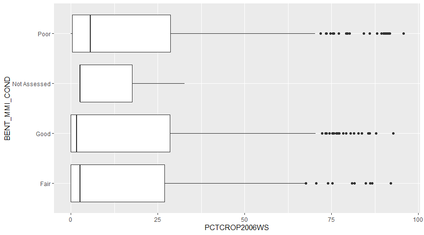

```r
# join mmi to NARS info data frame with StreamCat PctCrop metric
nrsa_sf <- left_join(nrsa_sf, mmi[,c('SITE_ID','BENT_MMI_COND')], by='SITE_ID')
nrsa_sf %>%
  drop_na(BENT_MMI_COND) %>%
  ggplot(aes(x=PCTCROP2006WS, y=BENT_MMI_COND))+
  geom_boxplot()
```